# Employee Data Analysis

Kati

8/7/2021

Link to recording: https://www.youtube.com/watch?v=O435FLjw810

Executive Summary The client, DDSAnalytics, is interested in leveraging data science for talent management, and has tasked my team with conducting an analysis of existing employee data, before green lighting the larger data science initiative. The following case study explores factors leading to attrition, using a data set provided by Frito Lay, in an effort to develop a model that will aid in predicting employee turnover.

Using ROC analysis of Naive Bayes on an undersampling of the data, it was determined that the top 3 contributors to employee turnover are: Overtime, Monthly Income, and Total Years Worked. Using these variables only, it was possible to determine whether an employee would experience attrition with an overall accuracy of approximately 66%.

We were also asked to identify the top variables contributing to employees’ monthly income. Using different automatic variable selection techniques on a linear regression model, it was determined that the top variables are: Business Travel, Job Level, Job Role, Percent Salary Hike, Performance Rating, and Total Working Years. Using a linear model created with these variables, it is possible to predict the mean monthly income for an employee with an accuracy of plus or minus $991.07, and to account for approximately 95.4% of the variation in the means of monthly income.

Import Libraries

```r
library(tidyverse)
library(e1071)
library(caret)
```

```r
library(corrplot)
library(class)
library(vcd)
library(olsrr)
library(MPV)
library(cowplot)
library(ggplot2)
library(GGally)
# library(MASS)
library(dplyr)
```

Code and Analysis

```r
#Data Import
empDataStart = read.csv(file.choose(), header = TRUE)
# head(empDataStart, n = 5)


# get column names
dfColumns = data.frame(colnames(empDataStart))
dfColumns
```

```
##      colnames.empDataStart.
## 1                        ID
## 2                       Age
## 3                 Attrition
## 4            BusinessTravel
## 5                 DailyRate
## 6                Department
## 7          DistanceFromHome
## 8                 Education
## 9            EducationField
## 10            EmployeeCount
## 11           EmployeeNumber
## 12  EnvironmentSatisfaction
## 13                   Gender
## 14               HourlyRate
```

[output cut: 22 more lines]

```r
# look at the data
head(empDataStart, n = 10)
```

```
##    ID Age Attrition    BusinessTravel DailyRate             Department
## 1   1  32        No     Travel_Rarely       117                  Sales
## 2   2  40        No     Travel_Rarely      1308 Research & Development
## 3   3  35        No Travel_Frequently       200 Research & Development
## 4   4  32        No     Travel_Rarely       801                  Sales
## 5   5  24        No Travel_Frequently       567 Research & Development
## 6   6  27        No Travel_Frequently       294 Research & Development
## 7   7  41        No     Travel_Rarely      1283 Research & Development
## 8   8  37        No     Travel_Rarely       309                  Sales
## 9   9  34        No     Travel_Rarely      1333                  Sales
## 10 10  34        No Travel_Frequently       653 Research & Development
##    DistanceFromHome Education   EducationField EmployeeCount EmployeeNumber
## 1                13         4    Life Sciences             1            859
## 2                14         3          Medical             1           1128
## 3                18         2    Life Sciences             1           1412
```

[output cut: 73 more lines]

```r
str(empDataStart)
```

```
## 'data.frame':    870 obs. of  36 variables:
##  $ ID                      : int  1 2 3 4 5 6 7 8 9 10 ...
##  $ Age                     : int  32 40 35 32 24 27 41 37 34 34 ...
##  $ Attrition               : chr  "No" "No" "No" "No" ...
##  $ BusinessTravel          : chr  "Travel_Rarely" "Travel_Rarely" "Travel_Frequently" "Travel_Rarely" ...
##  $ DailyRate               : int  117 1308 200 801 567 294 1283 309 1333 653 ...
##  $ Department              : chr  "Sales" "Research & Development" "Research & Development" "Sales" ...
##  $ DistanceFromHome        : int  13 14 18 1 2 10 5 10 10 10 ...
##  $ Education               : int  4 3 2 4 1 2 5 4 4 4 ...
##  $ EducationField          : chr  "Life Sciences" "Medical" "Life Sciences" "Marketing" ...
##  $ EmployeeCount           : int  1 1 1 1 1 1 1 1 1 1 ...
##  $ EmployeeNumber          : int  859 1128 1412 2016 1646 733 1448 1105 1055 1597 ...
##  $ EnvironmentSatisfaction : int  2 3 3 3 1 4 2 4 3 4 ...
##  $ Gender                  : chr  "Male" "Male" "Male" "Female" ...
##  $ HourlyRate              : int  73 44 60 48 32 32 90 88 87 92 ...
```

[output cut: 22 more lines]

```r
dim(empDataStart)
```

```
## [1] 870  36
```

```r
# Look at character columns.  Character columns with multiple levels that only contain one value
# add no value to the analysis and can cause operations to fail
empDataStart %>% keep(is.character) %>% sapply(., unique)
```

```
## $Attrition
## [1] "No"  "Yes"
##
## $BusinessTravel
## [1] "Travel_Rarely"     "Travel_Frequently" "Non-Travel"
##
## $Department
## [1] "Sales"                  "Research & Development" "Human Resources"
##
## $EducationField
## [1] "Life Sciences"    "Medical"          "Marketing"        "Technical Degree"
## [5] "Other"            "Human Resources"
##
## $Gender
## [1] "Male"   "Female"
##
## $JobRole
## [1] "Sales Executive"           "Research Director"
## [3] "Manufacturing Director"    "Research Scientist"
## [5] "Sales Representative"      "Healthcare Representative"
## [7] "Manager"                   "Human Resources"
## [9] "Laboratory Technician"
##
## $MaritalStatus
## [1] "Divorced" "Single"   "Married"
##
## $Over18
## [1] "Y"
##
## $OverTime
## [1] "No"  "Yes"
```

```r
# Over18 appears to be the only character with only one unique value represented.  We can remove
# it from the dataset

# Just like character variables with only one unique value, continuous variables (ints) that do not
# change from record to record add no value
empDataStart %>% keep(is.numeric) %>% sapply(., unique)
```

```
## $ID
##   [1]   1   2   3   4   5   6   7   8   9  10  11  12  13  14  15  16  17  18
##  [19]  19  20  21  22  23  24  25  26  27  28  29  30  31  32  33  34  35  36
##  [37]  37  38  39  40  41  42  43  44  45  46  47  48  49  50  51  52  53  54
##  [55]  55  56  57  58  59  60  61  62  63  64  65  66  67  68  69  70  71  72
##  [73]  73  74  75  76  77  78  79  80  81  82  83  84  85  86  87  88  89  90
##  [91]  91  92  93  94  95  96  97  98  99 100 101 102 103 104 105 106 107 108
## [109] 109 110 111 112 113 114 115 116 117 118 119 120 121 122 123 124 125 126
## [127] 127 128 129 130 131 132 133 134 135 136 137 138 139 140 141 142 143 144
## [145] 145 146 147 148 149 150 151 152 153 154 155 156 157 158 159 160 161 162
## [163] 163 164 165 166 167 168 169 170 171 172 173 174 175 176 177 178 179 180
## [181] 181 182 183 184 185 186 187 188 189 190 191 192 193 194 195 196 197 198
## [199] 199 200 201 202 203 204 205 206 207 208 209 210 211 212 213 214 215 216
## [217] 217 218 219 220 221 222 223 224 225 226 227 228 229 230 231 232 233 234
## [235] 235 236 237 238 239 240 241 242 243 244 245 246 247 248 249 250 251 252
```

[output cut: 356 more lines]

```r
# StandardHours is always 80
# EmployeeCount is always 1
# Other variables that do not add any information to the analysis can be
# database IDs, employee IDs, etc.  Let's look for those and remove them as well.
# ID
# Employee Number
# So, from this analysis, the following columns can be removed
# ID
# EmployeeCount
# EmployeeNumber
# Over18
# StandardHours
```

```r
# create new df
# remove some of the columns that do not have relevant info
## ID, DailyRate, EmployeeCount, HourlyRate, Over18, StandardHours
empData = subset(empDataStart, select = -c(ID, DailyRate, EmployeeCount, EmployeeNumber, Over18, StandardHours))
head(empData, n=5)
```

```
##   Age Attrition    BusinessTravel             Department DistanceFromHome
## 1  32        No     Travel_Rarely                  Sales               13
## 2  40        No     Travel_Rarely Research & Development               14
## 3  35        No Travel_Frequently Research & Development               18
## 4  32        No     Travel_Rarely                  Sales                1
## 5  24        No Travel_Frequently Research & Development                2
##   Education   EducationField EnvironmentSatisfaction Gender HourlyRate
## 1         4    Life Sciences                       2   Male         73
## 2         3          Medical                       3   Male         44
## 3         2    Life Sciences                       3   Male         60
## 4         4        Marketing                       3 Female         48
## 5         1 Technical Degree                       1 Female         32
##   JobInvolvement JobLevel                JobRole JobSatisfaction MaritalStatus
## 1              3        2        Sales Executive               4      Divorced
## 2              2        5      Research Director               3        Single
```

[output cut: 27 more lines]

```r
# get column names
# dfColumns = data.frame(colnames(empData))
# dfColumns
# dim(empData)

#Convert characters to factors
empData[sapply(empData, is.character)] <- lapply(empData[sapply(empData, is.character)],
                                                 as.factor)
#Check for NAs
# sapply(empData,function(x) sum(is.na(x)))

#Check number of levels for each factor
str(empData)
```

```
## 'data.frame':    870 obs. of  30 variables:
##  $ Age                     : int  32 40 35 32 24 27 41 37 34 34 ...
##  $ Attrition               : Factor w/ 2 levels "No","Yes": 1 1 1 1 1 1 1 1 1 1 ...
##  $ BusinessTravel          : Factor w/ 3 levels "Non-Travel","Travel_Frequently",..: 3 3 2 3 2 2 3 3 3 2 ...
##  $ Department              : Factor w/ 3 levels "Human Resources",..: 3 2 2 3 2 2 2 3 3 2 ...
##  $ DistanceFromHome        : int  13 14 18 1 2 10 5 10 10 10 ...
##  $ Education               : int  4 3 2 4 1 2 5 4 4 4 ...
##  $ EducationField          : Factor w/ 6 levels "Human Resources",..: 2 4 2 3 6 2 4 2 2 6 ...
##  $ EnvironmentSatisfaction : int  2 3 3 3 1 4 2 4 3 4 ...
##  $ Gender                  : Factor w/ 2 levels "Female","Male": 2 2 2 1 1 2 2 1 1 2 ...
##  $ HourlyRate              : int  73 44 60 48 32 32 90 88 87 92 ...
##  $ JobInvolvement          : int  3 2 3 3 3 3 4 2 3 2 ...
##  $ JobLevel                : int  2 5 3 3 1 3 1 2 1 2 ...
##  $ JobRole                 : Factor w/ 9 levels "Healthcare Representative",..: 8 6 5 8 7 5 7 8 9 1 ...
##  $ JobSatisfaction         : int  4 3 4 4 4 1 3 4 3 3 ...
```

[output cut: 16 more lines]

```r
#convert more columns for int to factor
empData$Education <- as.factor(empData$Education)
empData$JobInvolvement <- as.factor(empData$JobInvolvement)
empData$JobLevel <- as.factor(empData$JobLevel)
empData$JobSatisfaction <- as.factor(empData$JobSatisfaction)
empData$PerformanceRating <- as.factor(empData$PerformanceRating)
empData$RelationshipSatisfaction <- as.factor(empData$RelationshipSatisfaction)
empData$StockOptionLevel <- as.factor(empData$StockOptionLevel)
empData$WorkLifeBalance <- as.factor(empData$WorkLifeBalance)
```

Identifying Factors That Contribute to Attrition

One of the issues with this dataset is that it is very unbalanced. Only about 16% of the data contains a yes value attrition, so for any model it could identify everything as no attrition and still be approximately 84% - 85% accurate. To work around this I used a technique called under sampling. I first split the data set into the 140 rows containing yes for attrition and then a separate dataframe containing the no values. I then randomly sampled 140 of the no rows and combined them with the 140 yes rows. I then ran a Naive-Bayes classifier with Leave One Out Cross Validation on the combined dataframe and saved the top 3 variables that contributed to the attrition. I repeated this process 100 times, saving the top 3 variables each time. Using this process Overtime, Monthly Income, and Total Years Worked were identified as the top 3 variables contributing to attrition. This makes sense as we would except employees that feel overworked or underpaid to have higher levels of attrition.

```r
## take a look at the dispersion of attrition yes and attrition no
empData %>% group_by(empData$Attrition) %>% summarize(count=n())
```

```
## # A tibble: 2 x 2
##   `empData$Attrition` count
##   <fct>               <int>
## 1 No                    730
## 2 Yes                   140
```

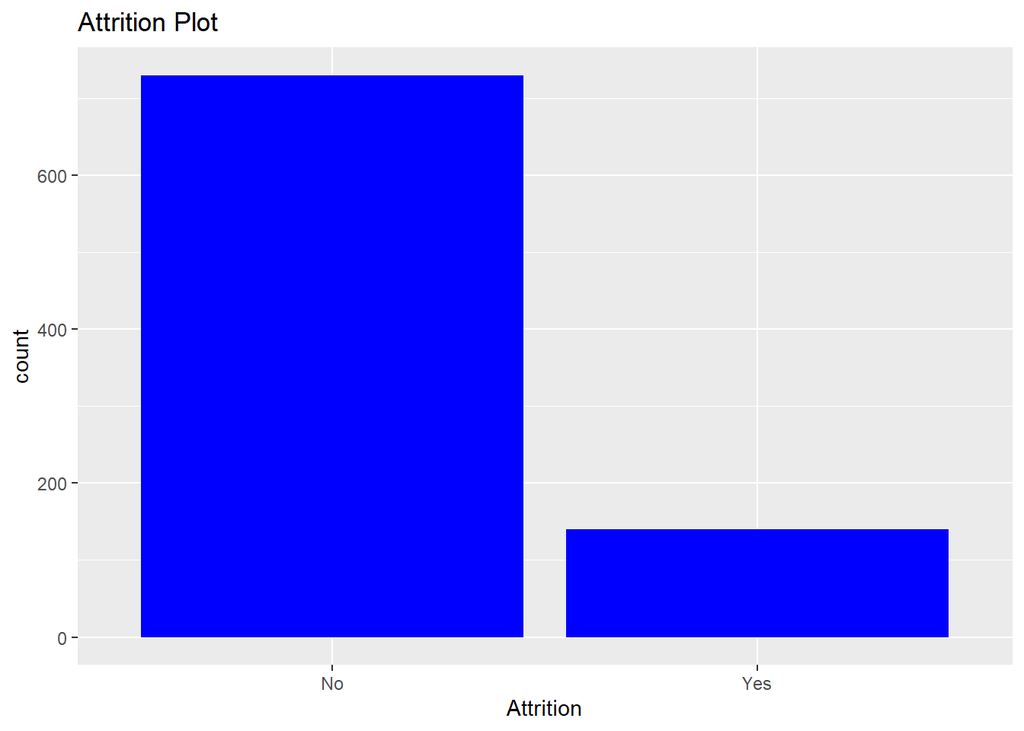

```r
# we have 730 Nos and 140 yes
# 84% No / 16% Yes
empData %>% ggplot(aes(x = Attrition)) + geom_bar(fill = "blue") +
  ggtitle("Attrition Plot")
```

```r
### This is having issues knitting - commenting out for html.
#split dataframe into separate frames for yes and no attrition
# atrYes = empData %>% filter(Attrition == "Yes")
# atrNo = empData %>% filter(Attrition == "No")
# Grid = data.frame(usekernel=TRUE,laplace = 1,adjust=1)
#
# # create dataframe to hold most important variables
# ImpName <- data.frame()
# # run naive bayes with loocv 100 times and select 3 most important variables using ROC
# # This testing uses under sampling in which 140 random no attrition values are selected to
# # compare to the 140 yes attrition values in the original Employee Data
# for(i in 1:100){
#   atrNoSample = sample_n(atrNo, 140)
#   dfAtr = data.frame()
#   dfAtr = rbind(atrYes, atrNoSample)
#
#   mdl = train(Attrition ~ .,data=dfAtr,method="naive_bayes",
#               trControl = trainControl(method="LOOCV"),
#               tuneGrid = Grid)
#
#   ImpMeasure = data.frame(varImp(mdl)$importance)
#   ImpMeasure$Name = row.names(ImpMeasure)
#   ImpMeasure = ImpMeasure[order(-ImpMeasure$Yes),]
#   ImpMeasure = ImpMeasure[1:3,] %>% dplyr::select(Name)
#   rownames(ImpMeasure) = NULL
#   ImpName = rbind(ImpName, ImpMeasure)
# }
#
# str(ImpName)
# ImpName %>% group_by(ImpName$Name) %>% summarize(count=n())
#
# ImpName %>% ggplot(aes(x = Name)) + geom_bar(fill = "blue",width=0.5,position="dodge") +
#   theme(legend.position="none",axis.text.x=element_text(angle=75,vjust=0.5)) +
#   ggtitle("Variable Importance") + ylab("Variable Count") + xlab("Variable Name")
```

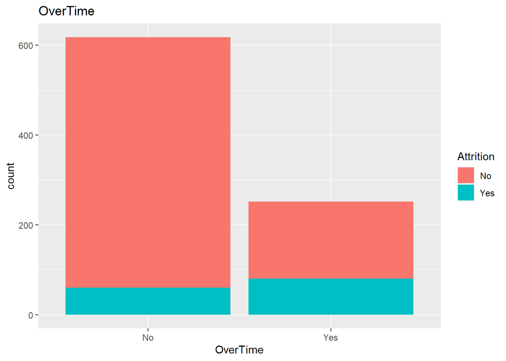

```r
# OverTime chart
empData %>%
  ggplot(aes(x = OverTime, fill = Attrition)) + geom_bar() +
  xlab("OverTime") + ggtitle("OverTime")
```

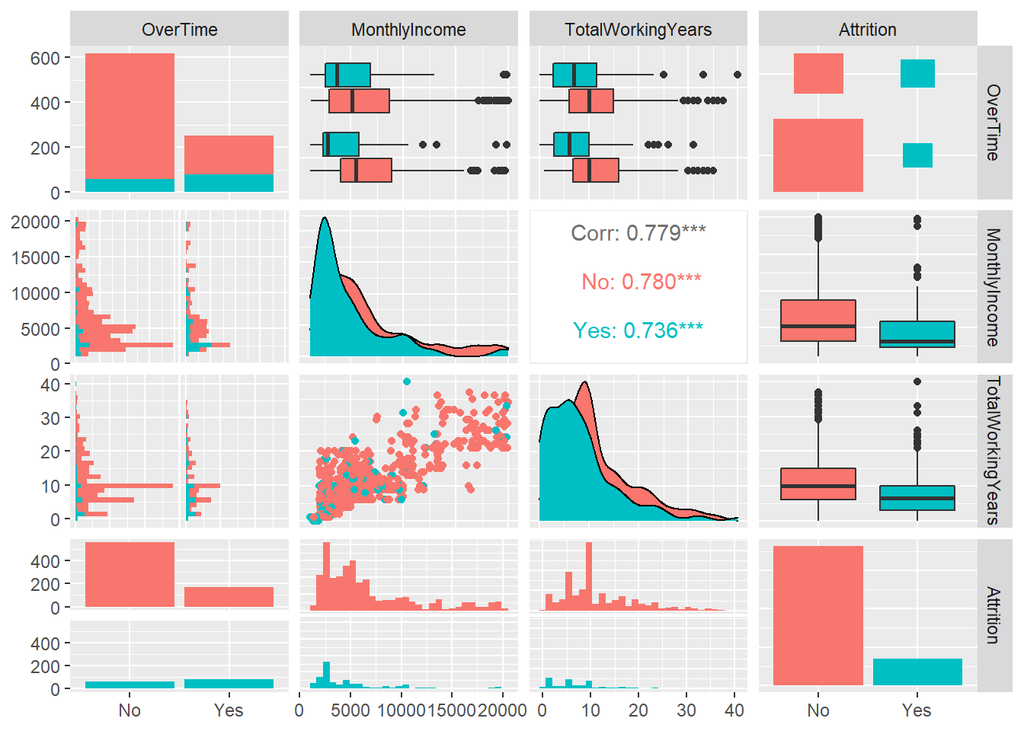

```r
empData %>% select(OverTime, MonthlyIncome, TotalWorkingYears,
                   Attrition) %>% ggpairs(aes(color = Attrition))
```

now that we know what variables we want to use, let’s see how they do at predicting attrition:

recall we have a data set in which people leaving (attrition = yes) is underrepresented - so we cannot just split our data into 70/30 train test - we need to randomly sample from the NO group

```r
##########################################################
# NaiveBayes performed better than KNN tests
##########################################################
# create new df with only our 3 most important columns + Attrition
# MonthlyIncome, OverTime,TotalWorkingYears
empDataNB = subset(empData, select = c(MonthlyIncome, OverTime,TotalWorkingYears, Attrition))
head(empDataNB, n=5)
```

```
##   MonthlyIncome OverTime TotalWorkingYears Attrition
## 1          4403       No                 8        No
## 2         19626       No                21        No
## 3          9362       No                10        No
## 4         10422       No                14        No
## 5          3760      Yes                 6        No
```

```r
#split dataframe into separate frames for yes and no attrition
atrYesNB = empDataNB %>% filter(Attrition == "Yes")
atrNoNB = empDataNB %>% filter(Attrition == "No")

iterations = 100

masterAcc = matrix(nrow = iterations)
masterSens = matrix(nrow = iterations)
masterSpec = matrix(nrow = iterations)

set.seed(7) # so we can replicate the results
splitPerc = 0.7


for(j in 1:iterations)
{
  atrNoSampleNB = sample_n(atrNoNB, 140)
  dfAtrNB <- data.frame()
  dfAtrNB = rbind(atrYesNB, atrNoSampleNB)

  trainIndices = sample(1:dim(dfAtrNB)[1], round(splitPerc * dim(dfAtrNB)[1]))
  dfTrain = dfAtrNB[trainIndices,]
  dfTest = dfAtrNB[-trainIndices,]

  model = naiveBayes(dfTrain[,c(1,2,3)], dfTrain$Attrition, laplace = 1)
  predict = table(predict(model,dfTest[,c(1,2,3)]),dfTest$Attrition)
  CM = confusionMatrix(predict)

  masterAcc[j] = CM$overall[1]
  masterSens[j] = CM$byClass["Sensitivity"]
  masterSpec[j] = CM$byClass["Specificity"]
}

meanAcc = mean(masterAcc)
meanSens = mean(masterSens)
meanSpec = mean(masterSpec)

meanAcc
```

```
## [1] 0.6577381
```

```r
meanSens
```

```
## [1] 0.609643
```

```r
meanSpec
```

```
## [1] 0.7136551
```

```r
# plot(masterAcc)
# CM
```

Other Insights

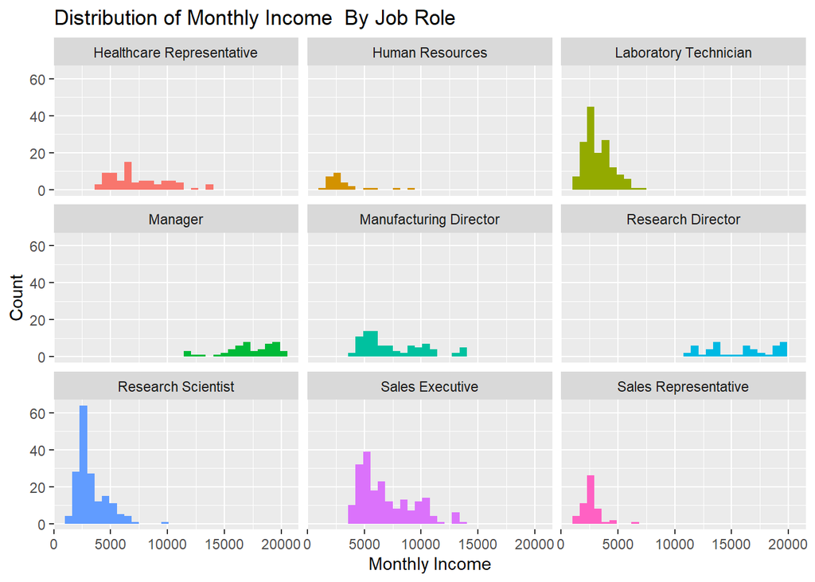

```r
# sales representatives have lower total working years and lower montly income
# this
#Monthly income by job role histogram
empData %>% ggplot(aes(x = MonthlyIncome, fill = JobRole)) + geom_histogram(show.legend = FALSE) + facet_wrap(~JobRole) +
  labs(title = "Distribution of Monthly Income  By Job Role", x = "Monthly Income", y = "Count")
```

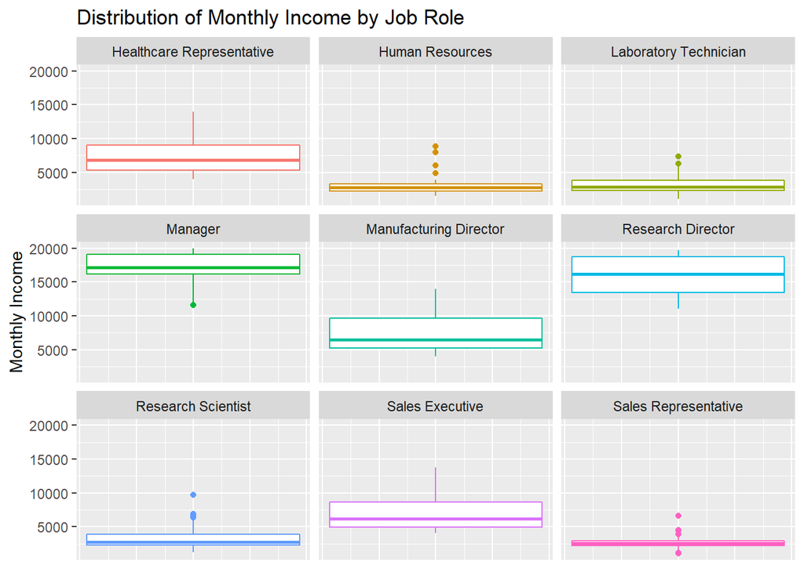

```r
#Monthly income by job role boxplot
empData %>% ggplot(aes(y = MonthlyIncome, color = JobRole)) + geom_boxplot(show.legend = FALSE) + facet_wrap(~JobRole) +
  labs(title = "Distribution of Monthly Income by Job Role", y = "Monthly Income") +
  theme(axis.title.x=element_blank(),axis.text.x=element_blank(), axis.ticks.x=element_blank())
```

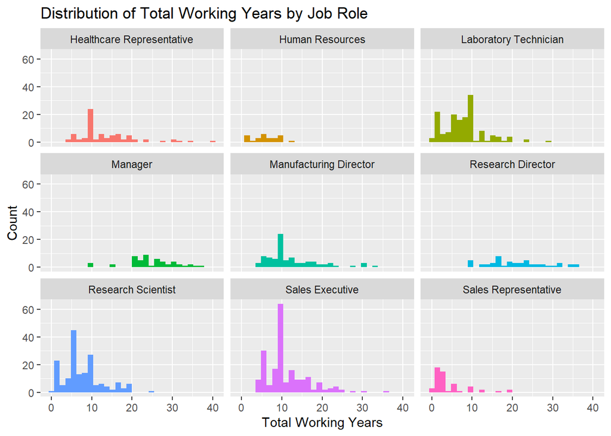

```r
#total working years by job role histogram
empData %>% ggplot(aes(x = TotalWorkingYears, fill = JobRole)) + geom_histogram(show.legend = FALSE) + facet_wrap(~JobRole) +
  labs(title = "Distribution of Total Working Years by Job Role", x = "Total Working Years", y = "Count")
```

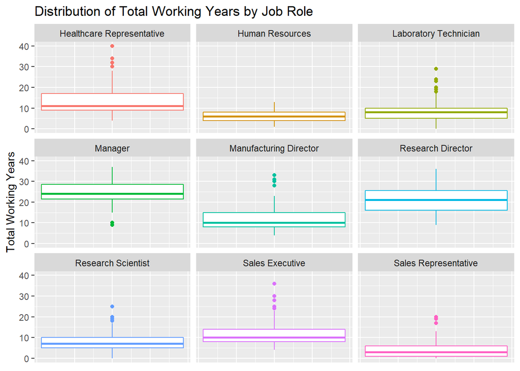

```r
#total working years by job role boxpot
empData %>% ggplot(aes(y = TotalWorkingYears, color = JobRole)) + geom_boxplot(show.legend = FALSE) + facet_wrap(~JobRole) +
  labs(title = "Distribution of Total Working Years by Job Role", y = "Total Working Years") +
  theme(axis.title.x=element_blank(),axis.text.x=element_blank(), axis.ticks.x=element_blank())
```

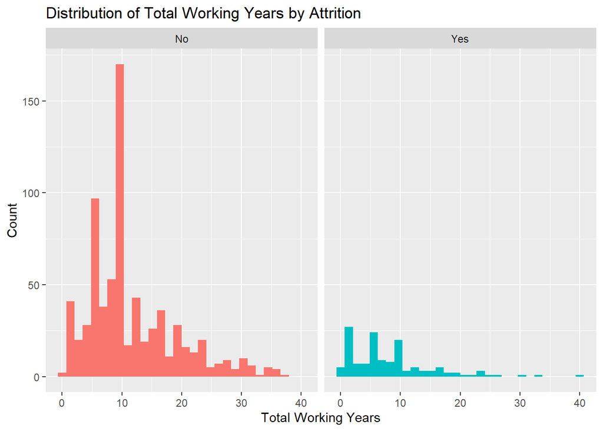

```r
#attrition by total working years
empData %>% ggplot(aes(x = TotalWorkingYears, fill = Attrition)) + geom_histogram(show.legend = FALSE) + facet_wrap(~Attrition) +
  labs(title = "Distribution of Total Working Years by Attrition", x = "Total Working Years", y = "Count")
```

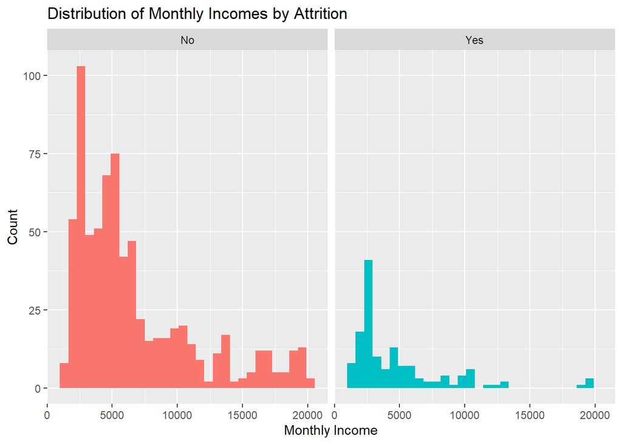

```r
#attrition by monthly income
empData %>% ggplot(aes(x = MonthlyIncome, fill = Attrition)) + geom_histogram(show.legend = FALSE) + facet_wrap(~Attrition) +
  labs(title = "Distribution of Monthly Incomes by Attrition", x = "Monthly Income", y = "Count")
```

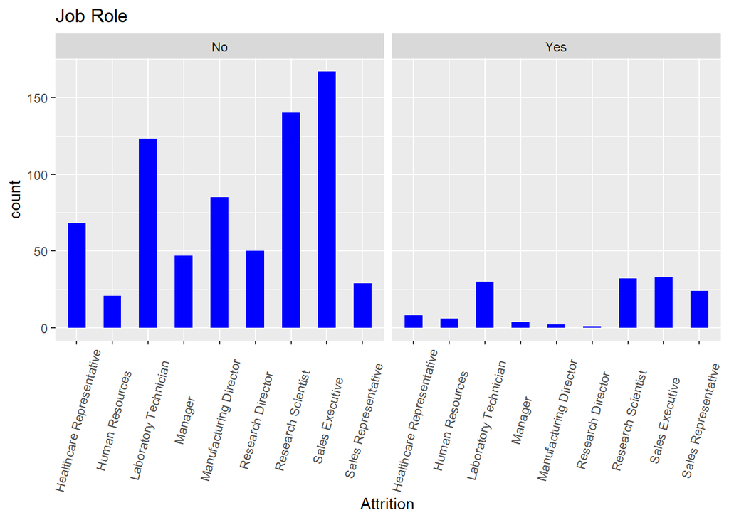

```r
# attrition by job role
empData %>% select(Attrition,YearsInCurrentRole, YearsSinceLastPromotion,
                   YearsWithCurrManager,YearsAtCompany,
                   MonthlyIncome, JobSatisfaction, JobRole) %>%
  ggplot(aes(x = JobRole, fill = Attrition)) +
  geom_bar(fill = "blue",width=0.5,position="dodge") +
  theme(legend.position="none",axis.text.x=element_text(angle=75,vjust=0.5)) +
  facet_wrap(~Attrition) + xlab("Attrition") + ggtitle("Job Role")
```

```r
######################################################
## EXTERNAL TEST DATA EXPORT - ATTRITION
######################################################
# externalTest = read.csv(file.choose(), header = TRUE)
#
# atrNoSampleNB = sample_n(atrNoNB, 140)
# dfAtrNB = data.frame()
# dfAtrNB = rbind(atrYesNB, atrNoSampleNB)
#
# trainIndices = sample(1:dim(dfAtrNB)[1], round(splitPerc * dim(dfAtrNB)[1]))
# dfTrain = dfAtrNB[trainIndices,]
# dfTest = dfAtrNB[-trainIndices,]
#
# model = naiveBayes(dfTrain[,c(1,2,3)], dfTrain$Attrition, laplace = 1)
#
# outPredict = predict(model,newdata = externalTest)
#
# outFile = cbind(externalTest$ID, outPredict)
# outFile = as.data.frame(outFile)
# outFile = outFile %>% rename(ID = V1, Attrition = outPredict)
# outFile = outFile %>% mutate(Attrition = as.factor(Attrition))
# levels(outFile$Attrition) <- c("No","Yes")
# outFile
# write.csv(outFile, file = "Case2PredictionsSchuerger_Attrition.csv", row.names = FALSE, quote = FALSE)
```

PREDICT SALARY Next, we were asked to find the Salary of employees from the data in the model, with a Root Mean Squared Error of less than $3000. To do this, we will build a multiple linear regression model using a stepwise iterative approach. The assumptions from above RE: unneccessary data still hold, and we will leave those out as well.

```r
set.seed(7)

#################### STEPAIC() STEPWISE SELECTION
# The stepAIC() function performs backward model selection by
# starting from a "maximal" model, which is then trimmed down.
# The "maximal" model is a linear regression model which assumes
# independent model errors and includes only main effects for the predictor variables

empDataLM = empData

linFit = lm(MonthlyIncome ~ ., data = empDataLM)
step = MASS::stepAIC(linFit, direction = "both") # both = stepwise
```

```
## Start:  AIC=12095.35
## MonthlyIncome ~ Age + Attrition + BusinessTravel + Department +
##     DistanceFromHome + Education + EducationField + EnvironmentSatisfaction +
##     Gender + HourlyRate + JobInvolvement + JobLevel + JobRole +
##     JobSatisfaction + MaritalStatus + MonthlyRate + NumCompaniesWorked +
##     OverTime + PercentSalaryHike + PerformanceRating + RelationshipSatisfaction +
##     StockOptionLevel + TotalWorkingYears + TrainingTimesLastYear +
##     WorkLifeBalance + YearsAtCompany + YearsInCurrentRole + YearsSinceLastPromotion +
##     YearsWithCurrManager
##
##                            Df  Sum of Sq        RSS   AIC
## - EducationField            5     844823  827798814 12086
## - JobSatisfaction           3    1374760  828328752 12091
## - StockOptionLevel          3    1384427  828338419 12091
## - JobInvolvement            3    1448144  828402136 12091
## - WorkLifeBalance           3    1522636  828476628 12091
## - RelationshipSatisfaction  3    1879698  828833690 12091
## - MaritalStatus             2     625977  827579969 12092
## - HourlyRate                1      13293  826967285 12093
## - Age                       1      96845  827050837 12093
## - Attrition                 1     108488  827062480 12094
## - OverTime                  1     110800  827064792 12094
## - EnvironmentSatisfaction   1     146713  827100704 12094
## - YearsWithCurrManager      1     410910  827364902 12094
## - YearsAtCompany            1     646664  827600656 12094
## - NumCompaniesWorked        1     675826  827629817 12094
## - TrainingTimesLastYear     1     688461  827642453 12094
## - Department                2    2750701  829704693 12094
## - MonthlyRate               1     931382  827885374 12094
## - Gender                    1    1129411  828083402 12094
## - DistanceFromHome          1    1293777  828247769 12095
## - YearsSinceLastPromotion   1    1308406  828262398 12095
## - YearsInCurrentRole        1    1491649  828445640 12095
## - PercentSalaryHike         1    1713743  828667735 12095
## <none>                                    826953992 12095
## - Education                 4    7791928  834745919 12096
## - PerformanceRating         1    3324007  830277999 12097
## - BusinessTravel            2    8800146  835754138 12101
## - TotalWorkingYears         1   15551798  842505790 12110
## - JobRole                   8  461409536 1288363528 12465
```

[output cut: 885 more lines]

```
## + OverTime                  1      34753  854491269 12042
## - PerformanceRating         1    3932535  858458557 12042
## + HourlyRate                1       5335  854520687 12042
## + Age                       1        149  854525873 12042
## + MaritalStatus             2     486185  854039837 12043
## + RelationshipSatisfaction  3    2362721  852163301 12044
## + JobSatisfaction           3    2039090  852486932 12044
## + WorkLifeBalance           3    1450760  853075262 12044
## + StockOptionLevel          3     923548  853602474 12045
## + JobInvolvement            3     590402  853935620 12045
## - BusinessTravel            2    9992841  864518863 12046
## + EducationField            5    1636776  852889246 12048
## - TotalWorkingYears         1   34976872  889502894 12073
## - JobRole                   8  490488507 1345014529 12418
## - JobLevel                  4 1400019480 2254545501 12876
```

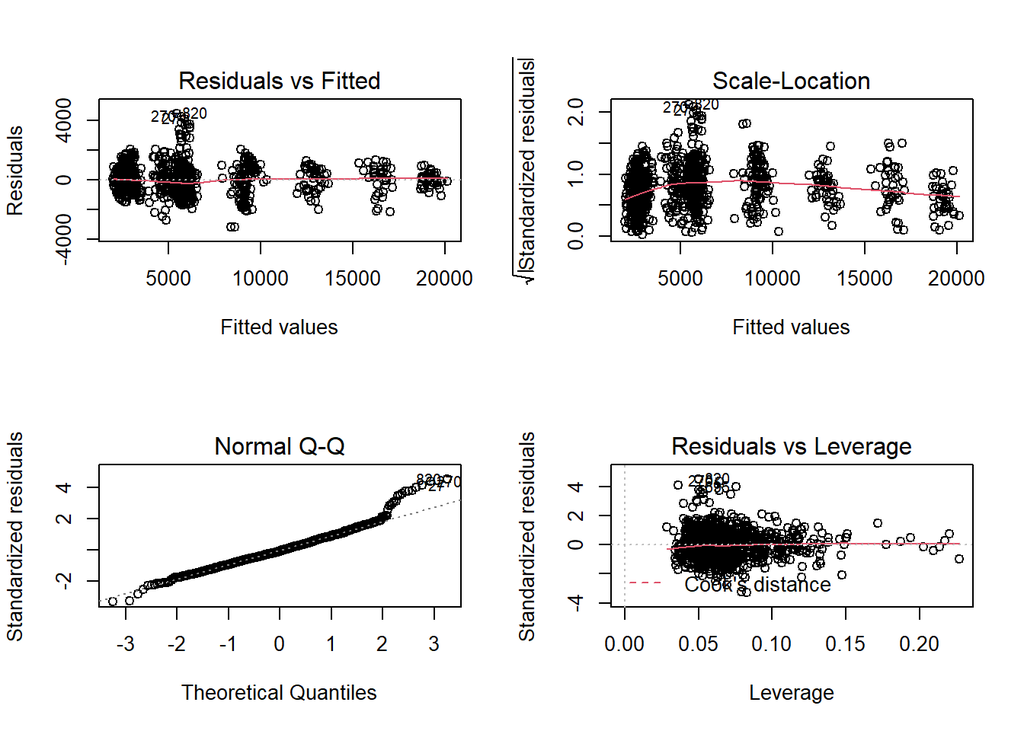

```r
# vcov(linFit)
# step$anova

# Final Model:
#   MonthlyIncome ~ BusinessTravel + JobLevel + JobRole + PercentSalaryHike +
#   PerformanceRating + TotalWorkingYears
# AIC 12039.88

# linear model fitness plots
layout(matrix(c(1,2,3,4),2,2))
plot(linFit)
```

```r
# QQ plot looks like our predictions are slightly skewed to the right
# but for the most part looks pretty good
# we will continue with this model

# MODEL FOR SALARY PREDICTION
linFitSW = lm(MonthlyIncome ~ BusinessTravel + JobLevel + JobRole + PercentSalaryHike +
     PerformanceRating + TotalWorkingYears, data = empDataLM)

# Function for Root Mean Squared Error
RMSE = function(error) { sqrt(mean(error^2)) }
RMSE(linFitSW$residuals)
```

```
## [1] 991.067
```

```r
summary(linFitSW)
```

```
##
## Call:
## lm(formula = MonthlyIncome ~ BusinessTravel + JobLevel + JobRole +
##     PercentSalaryHike + PerformanceRating + TotalWorkingYears,
##     data = empDataLM)
##
## Residuals:
##     Min      1Q  Median      3Q     Max
## -3224.8  -627.6   -86.7   606.2  4252.4
##
## Coefficients:
##                                  Estimate Std. Error t value Pr(>|t|)
## (Intercept)                      3050.410    297.578  10.251  < 2e-16 ***
## BusinessTravelTravel_Frequently   195.414    132.077   1.480    0.139
## BusinessTravelTravel_Rarely       332.588    111.761   2.976    0.003 **
## JobLevel2                        1710.248    138.686  12.332  < 2e-16 ***
## JobLevel3                        4926.403    186.483  26.417  < 2e-16 ***
## JobLevel4                        8241.330    281.707  29.255  < 2e-16 ***
## JobLevel5                       10959.441    331.461  33.064  < 2e-16 ***
## JobRoleHuman Resources          -1119.466    251.502  -4.451 9.68e-06 ***
## JobRoleLaboratory Technician    -1232.052    174.794  -7.049 3.73e-12 ***
## JobRoleManager                   3373.878    237.547  14.203  < 2e-16 ***
## JobRoleManufacturing Director     120.785    157.936   0.765    0.445
## JobRoleResearch Director         3477.976    210.524  16.521  < 2e-16 ***
## JobRoleResearch Scientist       -1042.384    177.933  -5.858 6.68e-09 ***
## JobRoleSales Executive             -9.320    136.230  -0.068    0.945
## JobRoleSales Representative     -1266.039    220.828  -5.733 1.37e-08 ***
## PercentSalaryHike                  22.159     14.792   1.498    0.135
## PerformanceRating4               -300.264    151.639  -1.980    0.048 *
## TotalWorkingYears                  45.657      7.731   5.905 5.08e-09 ***
## ---
## Signif. codes:  0 '***' 0.001 '**' 0.01 '*' 0.05 '.' 0.1 ' ' 1
##
## Residual standard error: 1001 on 852 degrees of freedom
## Multiple R-squared:  0.9535, Adjusted R-squared:  0.9526
## F-statistic:  1027 on 17 and 852 DF,  p-value: < 2.2e-16
```

```r
###################### FORWARD SELECTION
empDataLM = empData
  # subset(empData, select = -c(AttInd, OTInd))
mdl1 = lm(MonthlyIncome ~ ., data = empDataLM)

#automatic variable selection = FORWARD
SelectForward <- ols_step_forward_p(mdl1, peneter = 0.05, details = FALSE)
VarForward <- SelectForward$predictors
VarForward
```

```
##  [1] "JobLevel"          "JobRole"           "TotalWorkingYears"
##  [4] "BusinessTravel"    "Education"         "Department"
##  [7] "PerformanceRating" "PercentSalaryHike" "Gender"
## [10] "DistanceFromHome"
```

```r
# [1] "JobLevel" "JobRole" "TotalWorkingYears" "BusinessTravel" "Education"   "Department" "PerformanceRating"
# [8] "PercentSalaryHike" "Gender" "DistanceFromHome"


ForwardDF <- empData %>% dplyr::select(VarForward, MonthlyIncome)
```

```
## Note: Using an external vector in selections is ambiguous.
## i Use `all_of(VarForward)` instead of `VarForward` to silence this message.
## i See <https://tidyselect.r-lib.org/reference/faq-external-vector.html>.
```

```r
# get column names
dfColumns = data.frame(colnames(ForwardDF))
# dfColumns

# Fit a model
MdlFrwrd <- lm(MonthlyIncome ~ . , data = ForwardDF)

summary(MdlFrwrd)
```

```
##
## Call:
## lm(formula = MonthlyIncome ~ ., data = ForwardDF)
##
## Residuals:
##     Min      1Q  Median      3Q     Max
## -3234.7  -615.5   -84.2   589.3  4317.7
##
## Coefficients:
##                                   Estimate Std. Error t value Pr(>|t|)
## (Intercept)                       2847.809    527.013   5.404 8.50e-08 ***
## JobLevel2                         1735.691    140.060  12.393  < 2e-16 ***
## JobLevel3                         4975.146    187.249  26.570  < 2e-16 ***
## JobLevel4                         8342.579    284.025  29.373  < 2e-16 ***
## JobLevel5                        10983.519    333.501  32.934  < 2e-16 ***
## JobRoleHuman Resources            -871.941    488.100  -1.786  0.07439 .
## JobRoleLaboratory Technician     -1211.638    174.686  -6.936 8.02e-12 ***
## JobRoleManager                    3612.323    280.848  12.862  < 2e-16 ***
## JobRoleManufacturing Director      131.847    157.798   0.836  0.40365
## JobRoleResearch Director          3510.732    211.905  16.567  < 2e-16 ***
## JobRoleResearch Scientist        -1007.788    178.088  -5.659 2.09e-08 ***
## JobRoleSales Executive             546.420    336.067   1.626  0.10434
## JobRoleSales Representative       -690.082    378.201  -1.825  0.06841 .
## TotalWorkingYears                   44.816      7.793   5.751 1.24e-08 ***
## BusinessTravelTravel_Frequently    214.105    132.069   1.621  0.10536
## BusinessTravelTravel_Rarely        341.487    111.815   3.054  0.00233 **
## Education2                         -31.885    126.601  -0.252  0.80122
## Education3                         -97.102    116.614  -0.833  0.40526
## Education4                          52.879    122.994   0.430  0.66736
## Education5                        -412.279    227.034  -1.816  0.06973 .
## DepartmentResearch & Development   213.148    418.296   0.510  0.61049
## DepartmentSales                   -342.827    427.668  -0.802  0.42300
## PerformanceRating4                -284.565    151.827  -1.874  0.06124 .
## PercentSalaryHike                   21.057     14.811   1.422  0.15547
## GenderMale                          81.394     69.802   1.166  0.24391
## DistanceFromHome                    -4.687      4.222  -1.110  0.26731
## ---
## Signif. codes:  0 '***' 0.001 '**' 0.01 '*' 0.05 '.' 0.1 ' ' 1
##
## Residual standard error: 998.6 on 844 degrees of freedom
## Multiple R-squared:  0.9542, Adjusted R-squared:  0.9528
## F-statistic: 703.1 on 25 and 844 DF,  p-value: < 2.2e-16
```

```r
# Function for Root Mean Squared Error
RMSE = function(error) { sqrt(mean(error^2)) }
RMSE(MdlFrwrd$residuals)
```

```
## [1] 983.5325
```

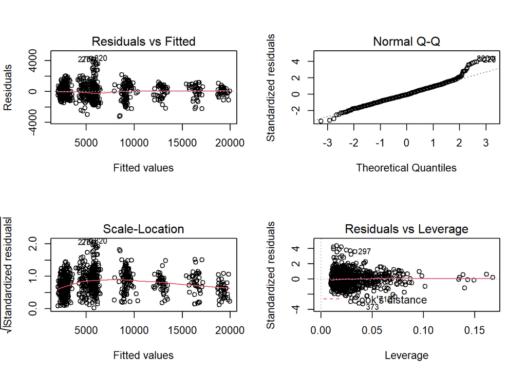

```r
# alternative way to get RMSE
# RMSE2 <- sqrt((c(crossprod(residuals(MdlFrwrd))) / length(residuals(MdlFrwrd))))
# RMSE2

par(mfrow = c(2,2))
plot(MdlFrwrd)
```

```r
     #, main = "Assumption Tests for Forward Selection Model")
par(mfrow = c(1,1))

###############################
# both stepwise and backward selection agree on the variables
# Final Model:
#   MonthlyIncome ~ BusinessTravel + JobLevel + JobRole + PercentSalaryHike +
#   PerformanceRating + TotalWorkingYears
# AIC 12039.88

# we will use this model to predict income (salary)

# 6 variables = STEP/BACKWARD = RMSE 991.067 (95.4% R2)
# 10 variables = FORWARD = RMSE 983.5325 (95.4% R2)

######################################################
## EXTERNAL TEST DATA EXPORT - SALARY
######################################################
# salaryData = read.csv(file.choose(), header = TRUE, sep = ",")
#
# dfColumnsSalary = data.frame(colnames(salaryData))
# dfColumnsSalary
#
# #Convert characters to factors
# salaryData[sapply(salaryData, is.character)] <- lapply(salaryData[sapply(salaryData, is.character)],
#                                                  as.factor)
# #Check for NAs
# # sapply(salaryData,function(x) sum(is.na(x)))
#
# #Check number of levels for each factor
# # str(salaryData)
#
# #convert more columns for int to factor
# salaryData$Education <- as.factor(salkaryData$Education)
# salaryData$JobInvolvement <- as.factor(salaryData$JobInvolvement)
# salaryData$JobLevel <- as.factor(salaryData$JobLevel)
# salaryData$JobSatisfaction <- as.factor(salaryData$JobSatisfaction)
# salaryData$PerformanceRating <- as.factor(salaryData$PerformanceRating)
# salaryData$RelationshipSatisfaction <- as.factor(salaryData$RelationshipSatisfaction)
# salaryData$StockOptionLevel <- as.factor(salaryData$StockOptionLevel)
# salaryData$WorkLifeBalance <- as.factor(salaryData$WorkLifeBalance)
#
# # fit the model on the prior data
# modelSal = lm(MonthlyIncome ~ BusinessTravel + JobLevel + JobRole + PercentSalaryHike +
#                 PerformanceRating + TotalWorkingYears, data = empDataLM)
#
# # predictions for external test data set
# outPredictSal = predict(modelSal,newdata = salaryData)
#
# # bind ID and our salary predictions
# outFileSal = cbind(externalTest$ID, outPredictSal)
# outFileSal = as.data.frame(outFileSal)
# head(outFileSal, n = 5)
#
# # rename columns
# outFileSal = outFileSal %>% rename(ID = V1, MonthlyIncome = outPredictSal)
#
# # We don't need fractional dollars here
# outFileSal$MonthlyIncome <- sapply(outFileSal$MonthlyIncome, round)
# head(outFileSal, n = 5)
#
# write.csv(outFileSal, file = "Case2PredictionsSchuerger_Salary.csv", row.names = FALSE, quote = FALSE)
```